# London_Household_Analysis

Danuphat

2024-10-15

```r
library(Rmisc)
library(emmeans)
library(tidyverse)
library(gridExtra)
options(width = 100)
```

This data analysis case is part of my assignment for the Business Analytics program at Warwick Business School. It has been modified to serve as a demonstration of my analytics portfolio. Accordingly, the analysis does not disclose any confidential insights or sensitive information related to private entities.

# Section 1 Techinical Report

This report is to provide analyses on data of children living in low income household in London, with specific analyses as requested.

1. Provide a table that shows each borough with the average, the standard deviation, the lowest number and the highest number of the children living in low income household.
2. Exclude specific unusual boroughs from the previous table.
3. Provided a visualisation of distribution of children in low income household in ward for each year. Furthermore, a visual should representation of the mean value and standard deviation for each year.
4. Perform a two sample t-test to see a significant difference between average number of children living in low income household in 2014 and 2021.

## Data Dictionary

The data is providing information of children living in low income household in each ward and borough in London. London is divided into boroughs and sub-divided into wards. The data is collected for each ward between 2014 to 2021. The variables are described in the table below

| Variable | Description |
| --- | --- |
| Ward code | Ward’s unique identifier |
| Wards (2018) | Ward name |
| Borough | Borough name |
| Year | Year of data collected, from 2014 to 2021 |
| Children | Number of children living in low income household (persons) |

## Read data

```r
# Import csv file into dataframe
dt <- read.csv('children_low_income_data.csv', stringsAsFactors = TRUE)
# Convert year as categorical data into factor format
dt <- dt %>%
  mutate(year = factor(year, c(2014, 2015, 2016, 2017, 2018, 2019, 2020, 2021)))
```

## Data integrity checking and cleaning

```r
str(dt) # Checking type of data stored in data frame
```

```
## 'data.frame':    5120 obs. of  5 variables:
##  $ Ward.code   : Factor w/ 640 levels "E05000026","E05000027",..: 1 1 1 1 1 1 1 1 2 2 ...
##  $ Wards..2018.: Factor w/ 622 levels "Abbey","Abbey Road",..: 1 1 1 1 1 1 1 1 12 12 ...
##  $ Borough     : Factor w/ 33 levels "Barking and Dagenham",..: 1 1 1 1 1 1 1 1 1 1 ...
##  $ year        : Factor w/ 8 levels "2014","2015",..: 1 2 3 4 5 6 7 8 1 2 ...
##  $ children    : int  1090 1119 1306 1417 1466 1631 1448 1314 693 725 ...
```

```r
summary(dt) # Checking overall statistical information and missing value (NA)
```

```
##      Ward.code       Wards..2018.        Borough          year         children
##  E05000026:   8   Abbey    :  16   Croydon   : 224   2014   : 640   Min.   :   5.0
##  E05000027:   8   Alexandra:  16   Ealing    : 184   2015   : 640   1st Qu.: 270.0
##  E05000028:   8   Barnhill :  16   Southwark : 184   2016   : 640   Median : 511.0
##  E05000029:   8   Belmont  :  16   Bromley   : 176   2017   : 640   Mean   : 570.1
##  E05000030:   8   Edgware  :  16   Hillingdon: 176   2018   : 640   3rd Qu.: 794.0
##  E05000031:   8   Fairfield:  16   Redbridge : 176   2019   : 640   Max.   :2094.0
##  (Other)  :5072   (Other)  :5024   (Other)   :4000   (Other):1280   NA's   :33
```

```r
# Found missing values (NA) in children variable which have to be removed before perform statistic calculation, the other variables seem to be accurate.
```

```r
# Remove missing value from data
rm.na.dt=na.omit(dt)
```

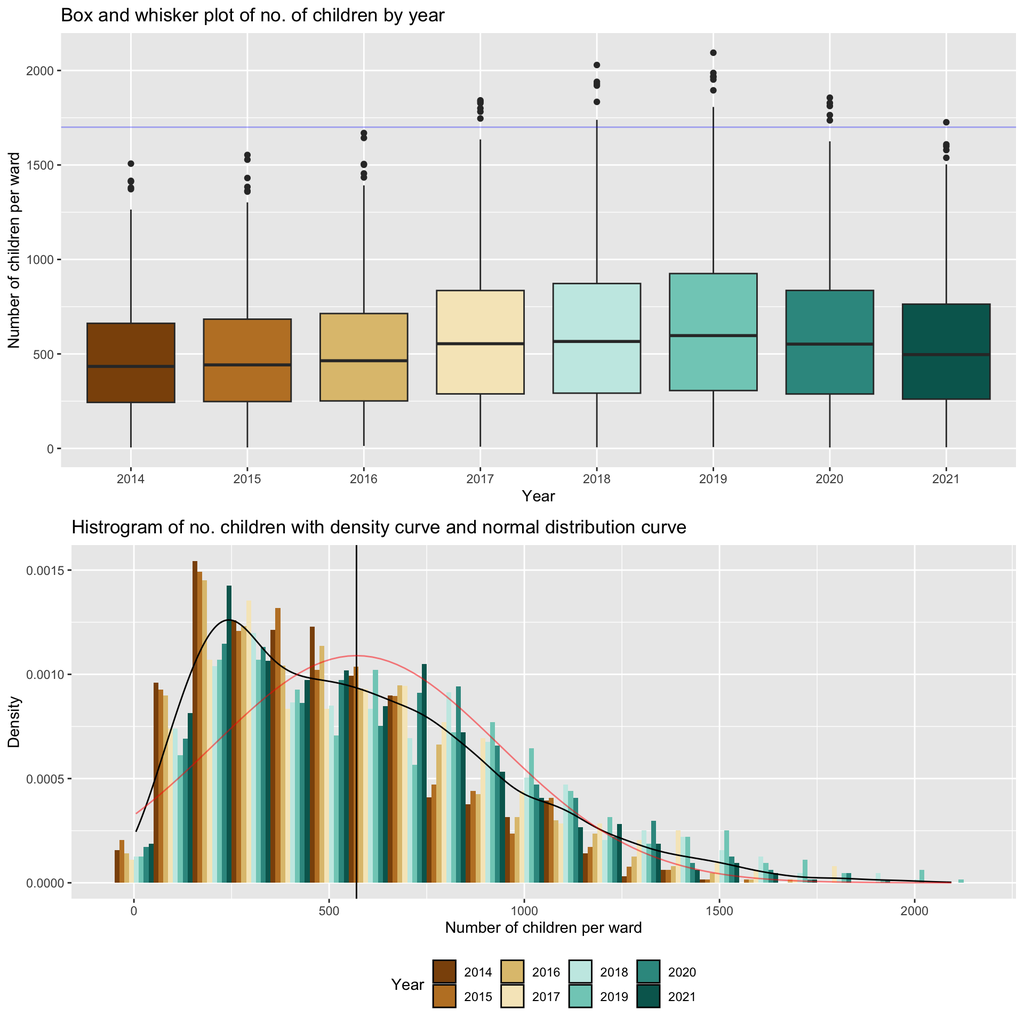

```r
# Visualise data to check overall outlier and skewness of the data
color_1 <- c("#8c510a", "#bf812d", "#dfc27d", "#f6e8c3", "#c7eae5", "#80cdc1", "#35978f", "#01665e")

grid.arrange(
  ggplot(data=rm.na.dt)+ # create box plot to spot outstanding outliers of each year
    geom_boxplot(aes(y=children, x=year, fill=year))+
    geom_hline(yintercept = 1700, col="blue", alpha=0.3)+
    labs(x="Year", y="Number of children per ward", title="Box and whisker plot of no. of children by year")+
    scale_fill_manual(values = color_1)+
    theme(legend.position="none") ,

  ggplot(data=rm.na.dt)+ # create histogram to identify skewness and distribution of the data
    geom_histogram(aes(x=children, y=..density.. ,fill = year),position = "dodge", binwidth = 100)+
    labs(x="Number of children per ward", y="Density", title="Histrogram of no. children with density curve and normal distribution curve")+
    scale_fill_manual(values = color_1, name="Year")+
    geom_vline(xintercept = mean(rm.na.dt$children))+
    geom_density(aes(x=children, y=..density..), alpha=0.5)+
    stat_function(fun=function(x) {dnorm(x, mean=mean(rm.na.dt$children), sd=sd(rm.na.dt$children))}, col="red", alpha=0.5)+
    theme(legend.position="bottom"),

  nrow=2
)
```

```r
# The charts show some outliers at above 1,700 children per ward, these outliers mostly come from 2017, 2018, 2019 and 2020, which in these years the number of children tend to increase in every borough, however, there was no obvious evidence that the outliers occur from error in collection process. In this case, removing these outliers will affect the statistic testing results as it will lead to increase p-value and less probability to reject Null hypothesis. Thus, these outliers will not be removed from the sampling in this case.

# The distribution of data is moderately positive skewed but due to the requests, the t-test will be performed in this analysis.
```

## 1 : Children in low income homes by borough

```r
# Group borough and calculate statistics information from removed missing value data
borough.table <- rm.na.dt %>%
  group_by(Borough) %>%
  summarise(Mean=mean(children), Standard_deviation=sd(children), Lowest=min(children), Highest=max(children))

print.data.frame(borough.table)
```

```
##                   Borough       Mean Standard_deviation Lowest Highest
## 1    Barking and Dagenham  987.06618          259.00079    551    1750
## 2                  Barnet  588.04167          340.07701    116    1807
## 3                  Bexley  506.03676          246.11281    174    1469
## 4                   Brent  707.53571          280.63079    249    1578
## 5                 Bromley  390.25568          210.68050    113    1062
## 6                  Camden  451.67361          268.40122     78    1373
## 7          City of London   26.48387           31.75833      5     156
## 8                 Croydon  570.49554          315.04882     48    1508
## 9                  Ealing  639.80978          313.80022    128    1327
## 10                Enfield  738.44048          408.98639    193    1895
## 11              Greenwich  839.75735          407.58051    211    1723
## 12                Hackney  697.01190          288.34265    231    1803
## 13 Hammersmith and Fulham  315.83594          199.42100     45    1042
## 14               Haringey  634.47368          407.23929     95    1691
```

[output cut: 19 more lines]

## 2 : Exclude unusual boroughs

```r
# Exclude unusual borough as requested by instruction
unusual.borough <- c("City of London", "Kensington and Chelsea", "Kingston upon Thames", "Richmond upon Thames", "Westminster") # Assign unusual borough name into vector
new.borough.dt <- borough.table %>%
  filter(!Borough %in% unusual.borough) # Filter unusual borough out

print.data.frame(new.borough.dt)
```

```
##                   Borough      Mean Standard_deviation Lowest Highest
## 1    Barking and Dagenham  987.0662           259.0008    551    1750
## 2                  Barnet  588.0417           340.0770    116    1807
## 3                  Bexley  506.0368           246.1128    174    1469
## 4                   Brent  707.5357           280.6308    249    1578
## 5                 Bromley  390.2557           210.6805    113    1062
## 6                  Camden  451.6736           268.4012     78    1373
## 7                 Croydon  570.4955           315.0488     48    1508
## 8                  Ealing  639.8098           313.8002    128    1327
## 9                 Enfield  738.4405           408.9864    193    1895
## 10              Greenwich  839.7574           407.5805    211    1723
## 11                Hackney  697.0119           288.3427    231    1803
## 12 Hammersmith and Fulham  315.8359           199.4210     45    1042
## 13               Haringey  634.4737           407.2393     95    1691
## 14                 Harrow  440.5714           179.3531    156     909
## 15               Havering  516.8889           276.2552    152    1405
## 16             Hillingdon  552.5455           336.7885    117    1416
## 17               Hounslow  599.0312           252.9930    141    1230
## 18              Islington  487.5156           149.5976    265     937
## 19                Lambeth  584.5893           202.9686    212    1247
## 20               Lewisham  729.0972           258.8086    351    1570
## 21                 Merton  379.5063           269.2068     38    1055
## 22                 Newham 1213.2625           250.2433    575    1987
## 23              Redbridge  689.3182           323.0706    133    1664
## 24              Southwark  563.4022           278.9336    108    1279
## 25                 Sutton  329.4306           153.4783    122     802
## 26          Tower Hamlets 1035.5062           449.1513    218    2094
## 27         Waltham Forest  797.1063           256.3304    269    1448
## 28             Wandsworth  392.2000           259.6240     85    1429
```

## 3 : Visualise data for different years

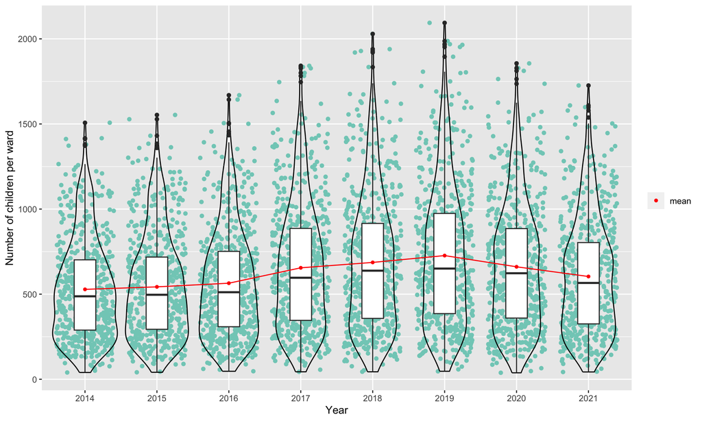

Figure 1. The distribution of number of children living in low income household from 2014 through 2021

```r
clean.dt <- rm.na.dt %>%
  filter(!Borough %in% unusual.borough)

q = c(0.25, 0.5, 0.75)
clean.dt.summary <- clean.dt %>% # Calculate statistics information from the data
  group_by(year) %>%
  summarize(mean = mean(children),Standard_deviation=sd(children),
            quant25 = quantile(children, probs = q[1]),
            quant50 = quantile(children, probs = q[2]),
            quant75 = quantile(children, probs = q[3]),
            n.total=sum(children))

plot.fig.1 <- ggplot(data=clean.dt, show.legend = FALSE, aes(y=children, x=year))+ # Create chart to show distribution change between 8 years
  geom_jitter(position = position_jitter(0.4), color="#80cdc1" )+
  geom_violin(color="black",  alpha=0.005)+
  geom_boxplot(width=0.3)+
  geom_line(data=clean.dt.summary, mapping = aes(x = year, y = mean, group=1),color="red")+
  stat_summary(show.legend = TRUE,fun = "mean", geom = "point", color = "red", aes(shape="mean"))+
  scale_shape_manual(values=c(16))+
  theme(legend.title= element_blank())+
  labs(y="Number of children per ward", x="Year")

plot.fig.1
```

## 4 : t-test comparing earliest and latest year

```r
dt.2014.2021 <- clean.dt %>%
  filter(year %in% c("2014", "2021"))
dt.2014.2021 %>%
  group_by(year) %>%
  summarise(mean=mean(children), sd=sd(children), n=n())
```

```
## # A tibble: 2 × 4
##   year   mean    sd     n
##   <fct> <dbl> <dbl> <int>
## 1 2014   528.  291.   560
## 2 2021   604.  336.   560
```

```r
# Null Hypothesis : mean of no. of children in lower income household from 2014 are not different from 2021.
# Alternative Hypothesis : mean of no. of children in lower income household from 2014 and 2021 are different.

t.test(children~year, data = dt.2014.2021)
```

```
##
##  Welch Two Sample t-test
##
## data:  children by year
## t = -4.0215, df = 1095.2, p-value = 6.18e-05
## alternative hypothesis: true difference in means between group 2014 and group 2021 is not equal to 0
## 95 percent confidence interval:
##  -112.4091  -38.6873
## sample estimates:
## mean in group 2014 mean in group 2021
##           528.3214           603.8696
```

```r
# linear model for compute confident interval for two sample
m.children.2014.2021 <- lm(children~year, data=dt.2014.2021)
(m.children.2014.2021.emm <- emmeans::emmeans(m.children.2014.2021, ~year))
```

```
##  year emmean   SE   df lower.CL upper.CL
##  2014    528 13.3 1118      502      554
##  2021    604 13.3 1118      578      630
##
## Confidence level used: 0.95
```

```r
(m.children.2014.2021.contrast <- confint(pairs(m.children.2014.2021.emm)))
```

```
##  contrast            estimate   SE   df lower.CL upper.CL
##  year2014 - year2021    -75.5 18.8 1118     -112    -38.7
##
## Confidence level used: 0.95
```

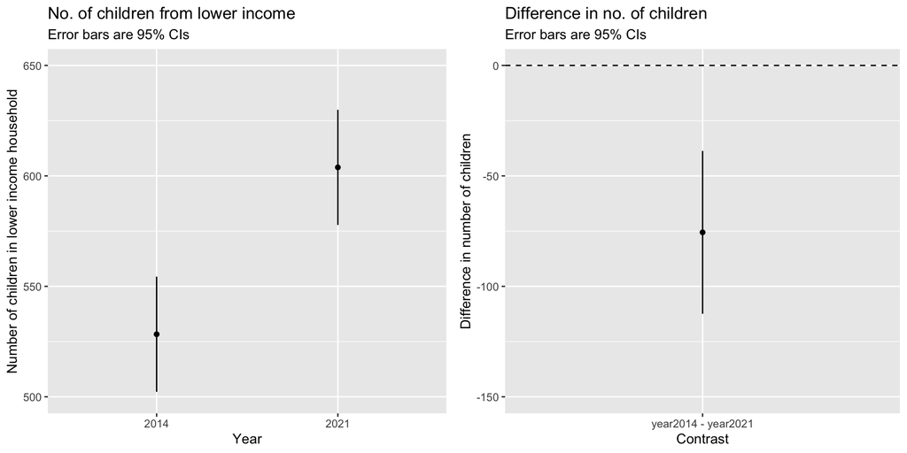

Figure 2. The confidence interval for the estimation of no. of children living in low income in 2014 and 2021 and the confidence interval for the difference between 2014 and 2021

```r
grid.arrange(
  ggplot(summary(m.children.2014.2021.emm), aes(x=year, y=emmean, ymin=lower.CL, ymax=upper.CL)) +
  geom_point() + geom_linerange() +
  labs(y="Number of children in lower income household", x="Year", subtitle="Error bars are 95% CIs", title="No. of children from lower income") +
  ylim(500,650),

  ggplot(m.children.2014.2021.contrast, aes(x=contrast, y=estimate, ymin=lower.CL, ymax=upper.CL)) +
  geom_point() + geom_linerange() +
  labs(y="Difference in number of children", x="Contrast", subtitle="Error bars are 95% CIs", title="Difference in no. of children")+ ylim(-150,0) +
  geom_hline(yintercept=0, lty=2),

  ncol=2)
```

# Section 2 : Executive Summary

This report presents the analysis of data on children living in low income households in London as requested. The 5,120 observations of data used in this analysis is provided by client. The analysis removes missing value and unusual data requested by client, but the inaccurate outliers does not evidently exist in this data. Thus, the data is used for this analysing is 4,480 observations from 28 boroughs, 560 wards, from 8 years.

The analysis begins with summary of mean and distribution of children living in low income household between 2014 and 2021.

In 2014, 50 percent of observations of children living in low income house per ward cluster between 289 to 702 persons (quartile 1 to quartile 3) with 528 persons in average, then steadily increase between 2014 and 2019. The highest number of children living in low income house are in 2019 which 50 percent of children per wards cluster between 386 to 974 persons and the average is 727 persons. Moreover, the distribution of number of children per wards are also at the peak in 2019 where the highest of children per ward is 2094 persons. After 2019, the number of children has gradually decrease toward 2020 and 2021, the 50 percent of observations in 2021 are between 326 to 803 persons with 604 persons in average.

The distribution of children living in low income house is shown in figure 1.

The next part is a t-test analysis comparing the first (2014) and the last (2021) year of information. The test shows that the average number of children from low income household in 2014 is 528 persons which is significant lower compared to 2021 which the average is 604 persons. Welch $t$(1095)=4.02, $p$<0.0001, with a difference of 76 persons.

The mean number of children from low income household in 2014 is 528 persons 95% CI [502-554]. While the mean number of children from low income household in 2021 is 604 persons 95% CI[578-630]. The difference in mean is 76 persons with 95% CI [39-112] smaller at 2014 compared to 2021.

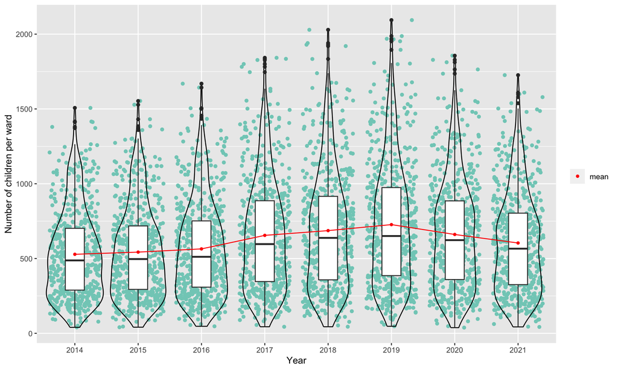

Figure 1. The distribution of number of children living in low income household from 2014 through 2021

```r
print.data.frame(new.borough.dt)
```

```
##                   Borough      Mean Standard_deviation Lowest Highest
## 1    Barking and Dagenham  987.0662           259.0008    551    1750
## 2                  Barnet  588.0417           340.0770    116    1807
## 3                  Bexley  506.0368           246.1128    174    1469
## 4                   Brent  707.5357           280.6308    249    1578
## 5                 Bromley  390.2557           210.6805    113    1062
## 6                  Camden  451.6736           268.4012     78    1373
## 7                 Croydon  570.4955           315.0488     48    1508
## 8                  Ealing  639.8098           313.8002    128    1327
## 9                 Enfield  738.4405           408.9864    193    1895
## 10              Greenwich  839.7574           407.5805    211    1723
## 11                Hackney  697.0119           288.3427    231    1803
## 12 Hammersmith and Fulham  315.8359           199.4210     45    1042
## 13               Haringey  634.4737           407.2393     95    1691
## 14                 Harrow  440.5714           179.3531    156     909
## 15               Havering  516.8889           276.2552    152    1405
## 16             Hillingdon  552.5455           336.7885    117    1416
## 17               Hounslow  599.0312           252.9930    141    1230
## 18              Islington  487.5156           149.5976    265     937
## 19                Lambeth  584.5893           202.9686    212    1247
## 20               Lewisham  729.0972           258.8086    351    1570
## 21                 Merton  379.5063           269.2068     38    1055
## 22                 Newham 1213.2625           250.2433    575    1987
## 23              Redbridge  689.3182           323.0706    133    1664
## 24              Southwark  563.4022           278.9336    108    1279
## 25                 Sutton  329.4306           153.4783    122     802
## 26          Tower Hamlets 1035.5062           449.1513    218    2094
## 27         Waltham Forest  797.1063           256.3304    269    1448
## 28             Wandsworth  392.2000           259.6240     85    1429
```